# Exploratory Analysis

Putting categorical and numerical summaries into code

## Getting started

This lab picks up where our RStudio/tidyverse basics left off. This week we saw how to *describe* categorical data (bar plots, contingency tables) and numerical data (histograms, boxplots, mean/median, variance/SD) by hand and by sight. Today we’ll build those same summaries and plots in code, using one dataset throughout: `nycflights`, a random sample of domestic flights departing the three major NYC airports in 2013.

```r
library(tidyverse)
library(openintro)
data(nycflights)
```

Take a first look:

```r
glimpse(nycflights)
```

```
Rows: 32,735
Columns: 16
$ year      <int> 2013, 2013, 2013, 2013, 2013, 2013, 2013, 2013, 2013, 2013, …
$ month     <int> 6, 5, 12, 5, 7, 1, 12, 8, 9, 4, 6, 11, 4, 3, 10, 1, 2, 8, 10…
$ day       <int> 30, 7, 8, 14, 21, 1, 9, 13, 26, 30, 17, 22, 26, 25, 21, 23, …
$ dep_time  <int> 940, 1657, 859, 1841, 1102, 1817, 1259, 1920, 725, 1323, 940…
$ dep_delay <dbl> 15, -3, -1, -4, -3, -3, 14, 85, -10, 62, 5, 5, -2, 115, -4, …
$ arr_time  <int> 1216, 2104, 1238, 2122, 1230, 2008, 1617, 2032, 1027, 1549, …
$ arr_delay <dbl> -4, 10, 11, -34, -8, 3, 22, 71, -8, 60, -4, -2, 22, 91, -6, …
$ carrier   <chr> "VX", "DL", "DL", "DL", "9E", "AA", "WN", "B6", "AA", "EV", …
$ tailnum   <chr> "N626VA", "N3760C", "N712TW", "N914DL", "N823AY", "N3AXAA", …
$ flight    <int> 407, 329, 422, 2391, 3652, 353, 1428, 1407, 2279, 4162, 20, …
$ origin    <chr> "JFK", "JFK", "JFK", "JFK", "LGA", "LGA", "EWR", "JFK", "LGA…
$ dest      <chr> "LAX", "SJU", "LAX", "TPA", "ORF", "ORD", "HOU", "IAD", "MIA…
$ air_time  <dbl> 313, 216, 376, 135, 50, 138, 240, 48, 148, 110, 50, 161, 87,…
$ distance  <dbl> 2475, 1598, 2475, 1005, 296, 733, 1411, 228, 1096, 820, 264,…
$ hour      <dbl> 9, 16, 8, 18, 11, 18, 12, 19, 7, 13, 9, 13, 8, 20, 12, 20, 6…
$ minute    <dbl> 40, 57, 59, 41, 2, 17, 59, 20, 25, 23, 40, 20, 9, 54, 17, 24…
```

Some variables you’ll use today:

- **Categorical:** `carrier` (airline), `origin` (JFK/LGA/EWR), `dest`, `month`
- **Numerical:** `dep_delay`, `arr_delay`, `distance`, `air_time`

## Part 1: Wrangling review

Before we visualize, a quick refresher on the verbs that get data into plotting shape.

### Filtering

Keep only the rows you care about with `filter()`. Flights headed to Los Angeles:

```r
lax_flights <- nycflights |>
  filter(dest == "LAX")
```

Multiple conditions — flights to San Francisco in February:

```r
sfo_feb_flights <- nycflights |>
  filter(dest == "SFO", month == 2)
```

### Creating new variables

`mutate()` adds a column. Classify each flight as on-time or delayed:

```r
nycflights <- nycflights |>
  mutate(dep_type = ifelse(dep_delay < 5, "on time", "delayed"))
```

### Grouping and summarizing

`group_by()` + `summarise()` is how you get one row of stats per category:

```r
nycflights |>
  group_by(origin) |>
  summarise(
    median_dd = median(dep_delay),
    iqr_dd    = IQR(dep_delay),
    n_flights = n()
  )
```

```
# A tibble: 3 × 4
  origin median_dd iqr_dd n_flights
  <chr>      <dbl>  <dbl>     <int>
1 EWR           -1     19     11771
2 JFK           -1     15     10897
3 LGA           -3     13     10067
```

### Sorting

`arrange(desc(...))` puts the largest values first:

```r
nycflights |>
  group_by(month) |>
  summarise(mean_dd = mean(dep_delay)) |>
  arrange(desc(mean_dd))
```

```
# A tibble: 12 × 2
   month mean_dd
   <int>   <dbl>
 1     7   20.8
 2     6   20.4
 3    12   17.4
 4     4   14.6
 5     3   13.5
 6     5   13.3
 7     8   12.6
 8     2   10.7
 9     1   10.2
10     9    6.87
11    11    6.10
12    10    5.88
```

**Try it:** Which origin airport has the best on-time departure *rate* (proportion of flights with `dep_type == "on time"`)? Write the pipe chain to find out.

## Part 2: Visualizing — matching the plot to the variable(s)

Every `ggplot2` call follows the same recipe: `ggplot(data, aes(...)) + geom_...()`. The **geom** you choose depends on how many variables you have and whether they’re categorical or numerical — this is the same decision tree from Monday and Wednesday’s lectures, just now in code.

### One categorical variable → bar plot

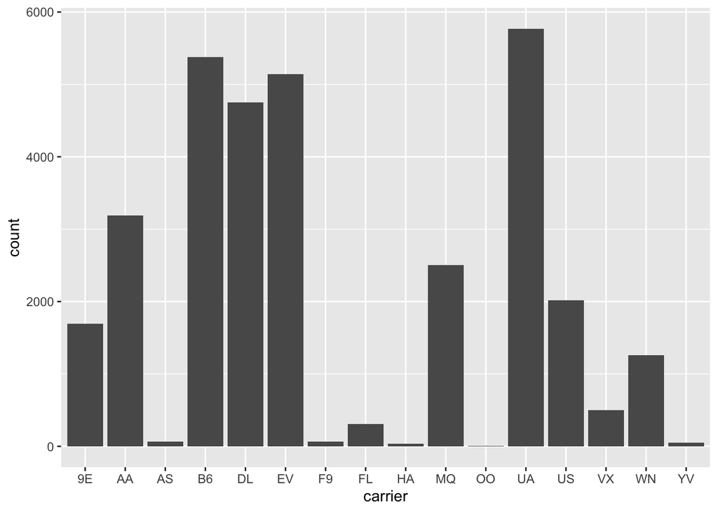

```r
ggplot(data = nycflights, aes(x = carrier)) +
  geom_bar()
```

Relative frequency instead of counts — divide by the total, or let `ggplot` do proportions directly:

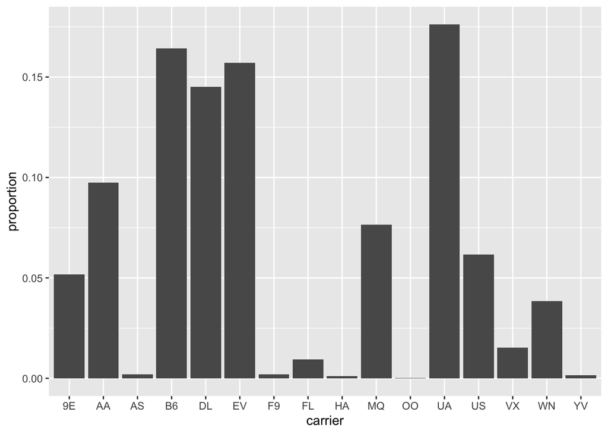

```r
ggplot(data = nycflights, aes(x = carrier, y = after_stat(count) / sum(after_stat(count)))) +
  geom_bar() +
  ylab("proportion")
```

### One numerical variable → histogram, density, or boxplot

Histogram — the shape of a single distribution:

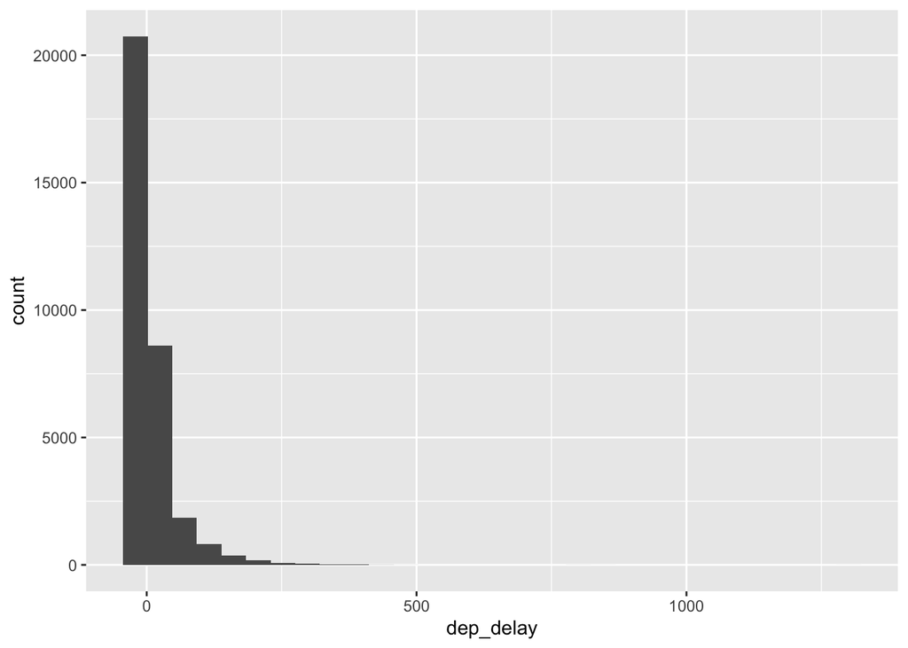

```r
ggplot(data = nycflights, aes(x = dep_delay)) +
  geom_histogram()
```

Binwidth changes the story (recall Wednesday’s discussion of bin width):

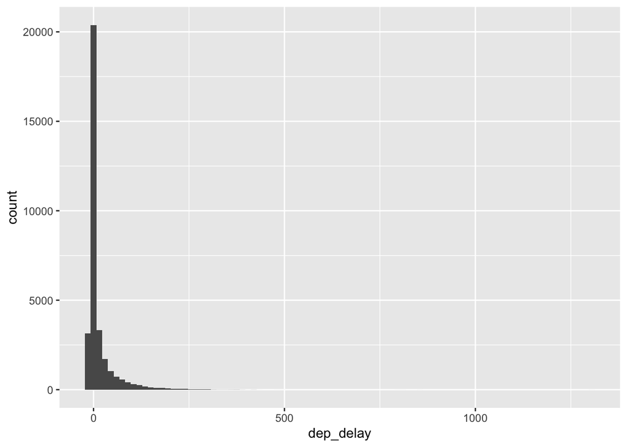

```r
ggplot(data = nycflights, aes(x = dep_delay)) +
  geom_histogram(binwidth = 15)
```

Density plot — a smoothed version of the histogram:

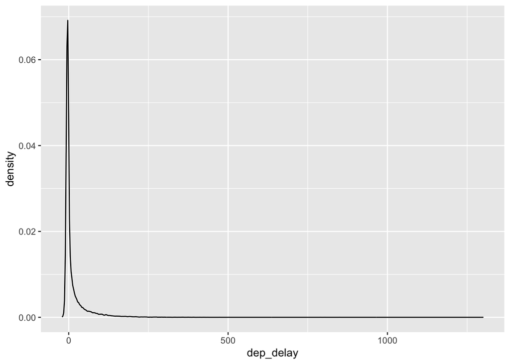

```r
ggplot(data = nycflights, aes(x = dep_delay)) +
  geom_density()
```

Boxplot — center, spread, and outliers at a glance:

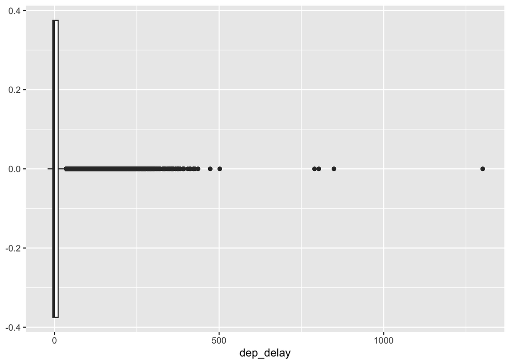

```r
ggplot(data = nycflights, aes(x = dep_delay)) +
  geom_boxplot()
```

### Two categorical variables → stacked or grouped bar plot

Is on-time performance related to which airport you fly out of?

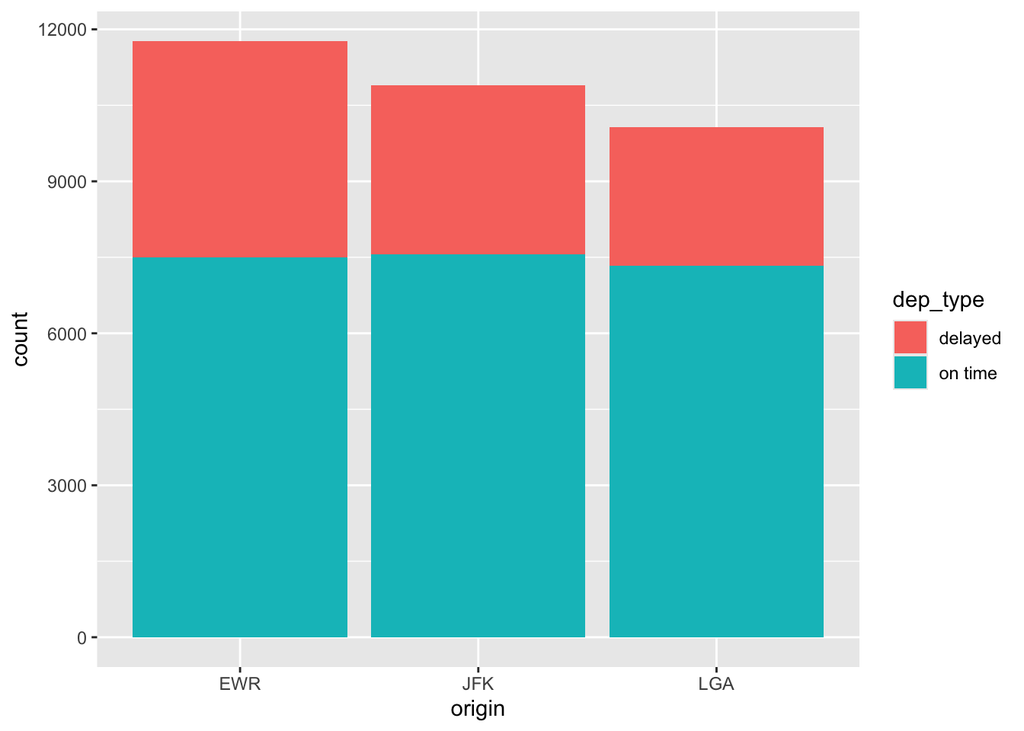

```r
ggplot(data = nycflights, aes(x = origin, fill = dep_type)) +
  geom_bar()
```

As proportions instead of counts (a **standardized/filled** bar plot — same idea as the row proportions we calculated by hand Monday):

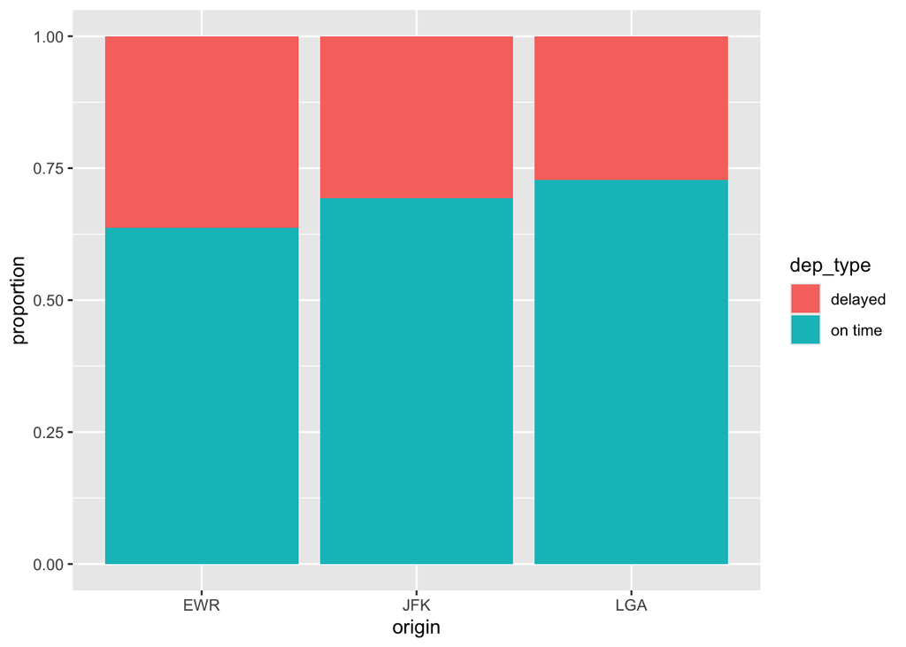

```r
ggplot(data = nycflights, aes(x = origin, fill = dep_type)) +
  geom_bar(position = "fill") +
  ylab("proportion")
```

Side-by-side instead of stacked:

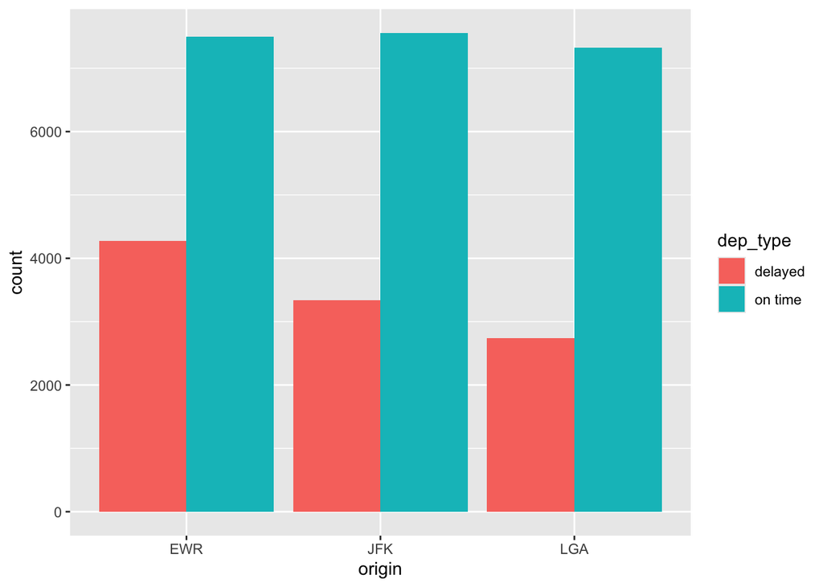

```r
ggplot(data = nycflights, aes(x = origin, fill = dep_type)) +
  geom_bar(position = "dodge")
```

### One numerical + one categorical → side-by-side boxplots

Do departure delays vary by origin airport?

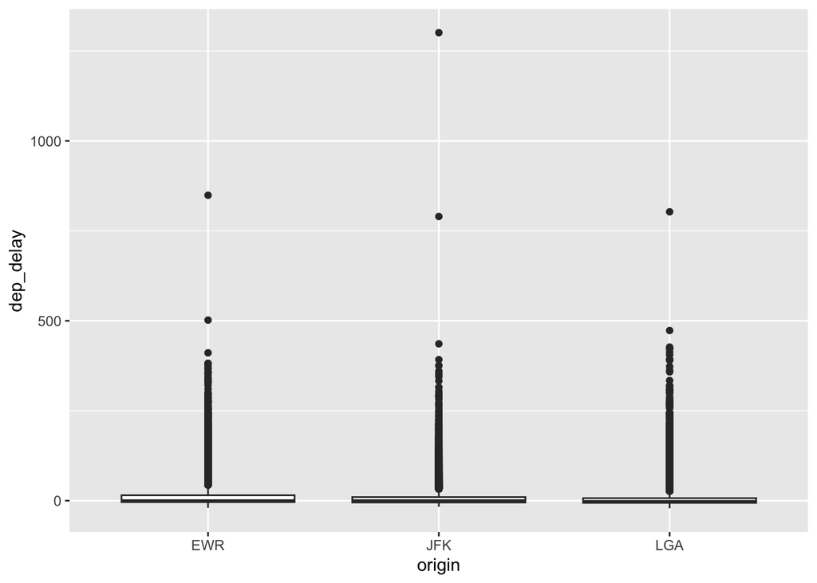

```r
ggplot(data = nycflights, aes(x = origin, y = dep_delay)) +
  geom_boxplot()
```

### Two numerical variables → scatterplot

Does flight distance predict air time?

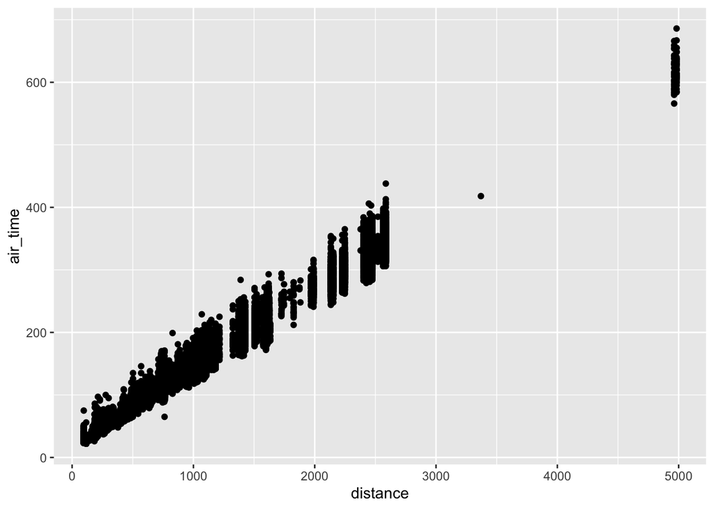

```r
ggplot(data = nycflights, aes(x = distance, y = air_time)) +
  geom_point()
```

Add a trend line to see the relationship more clearly:

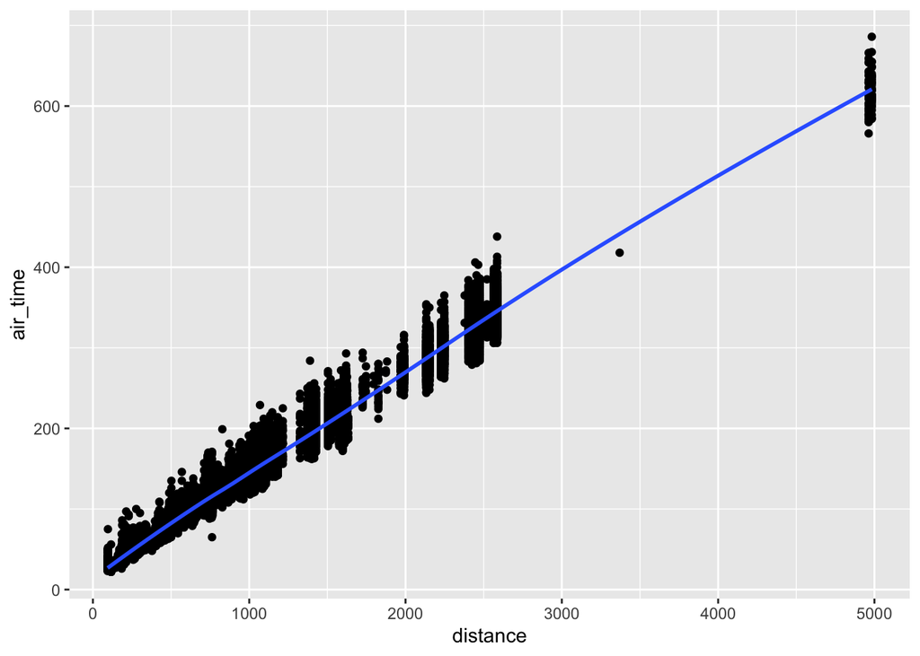

```r
ggplot(data = nycflights, aes(x = distance, y = air_time)) +
  geom_point() +
  geom_smooth(method = "loess", se = FALSE)
```

### Bonus: splitting a plot by a third variable (faceting)

If you want to see the distance/air-time relationship separately for each origin airport, instead of coloring points you can facet into small multiples:

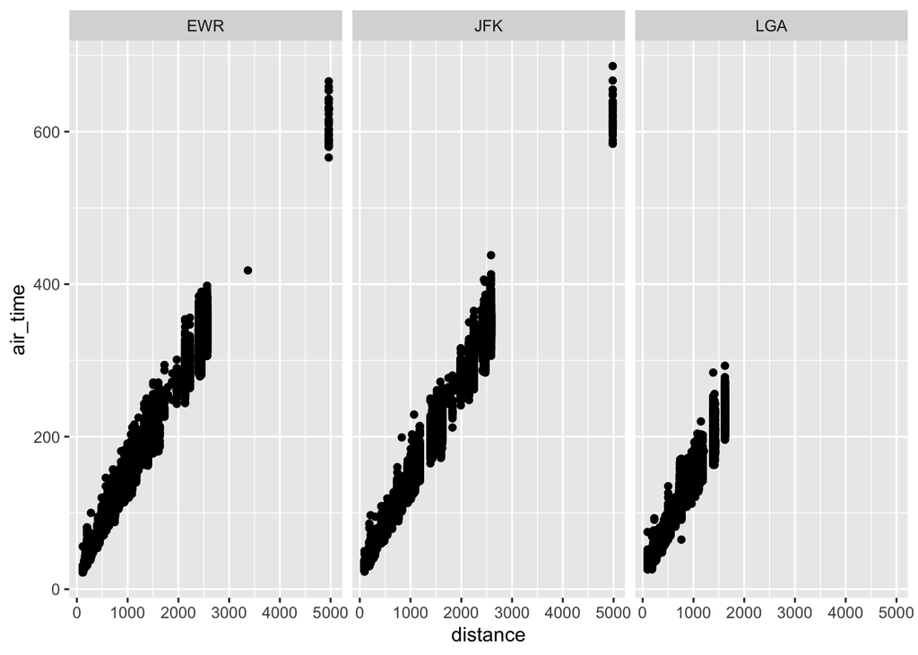

```r
ggplot(data = nycflights, aes(x = distance, y = air_time)) +
  geom_point() +
  facet_wrap(~ origin)
```

## Part 3: In-class exercise

Using `nycflights`, answer the following. For each, decide what type of variable(s) you have first — that tells you what plot to reach for.

1. Make a plot showing the distribution of `arr_delay` for flights **only** headed to `"ORD"`. Describe the shape (modality, skew, outliers).
2. Compare `arr_delay` across the three origin airports with a single plot. Which airport looks most consistent (least variable)?
3. Is there a relationship between `dep_delay` and `arr_delay`? Make an appropriate plot and describe what you see.
4. Make a bar plot showing how many flights each `carrier` had that were `"delayed"` vs. `"on time"`. Which carrier has the worst on-time rate?
5. **Open-ended:** Come up with your own question about `nycflights` that involves at least one numerical and one categorical variable, then answer it with a plot.

*(If you’d rather work with a different dataset for #5, `cubs_all_time.csv` also works well here — swap in `read_csv("cubs_all_time.csv")` for the `data` argument in any of the geoms above.)*